# A social media visual data story

## Short form content and untangling the algorithm

The focus of this report is exploring the different types of content which a user encounters in a social media session.

The rise of short form content in social media can be accredited to the term “Brain rot” being crowned Oxford word of the year [1](https://corp.oup.com/news/brain-rot-named-oxford-word-of-the-year-2024/). Brain rot is described as a term “used to capture concerns about the impact of consuming excessive amounts of low-quality online content, especially on social media.”. Like many social constructs the term “Brain rot” is an evolving concept. In this analysis I wanted to record the types of content which a user sees when going on a social media session. This is recorded in a from which the user completes after each social media session. A social media session, in this context, was defined as the time from opening a social media site or app to exiting the app for any reason. The estimated time of each social media session was recorded, if the user viewed any short form content, and if so what types of content classified into 6 categories, how often they saw this content, as well as the estimated percentage of shorts that comprised their last social media session. After the user submits the form it is automatically sent to a google spreadsheet where analysis can be done. The data provided is from my own observations using the form

## To short or not to short?

Our analysis tells us that majority of time, the respondent (me), ended up watching short form content in some way whenever logging onto a social media site. We can see that the time recorded is spread out throughout the waking hours. Sessions where short form content were more sporadic, likely due to the small sample size.

### **So what?**

Our plot tells us that we tend to stay active longer on a social media site if there is some form of short form content. I am no psychologist but it may be worth investigating the impact that these shorts have on our attention span and dopamine receptors.

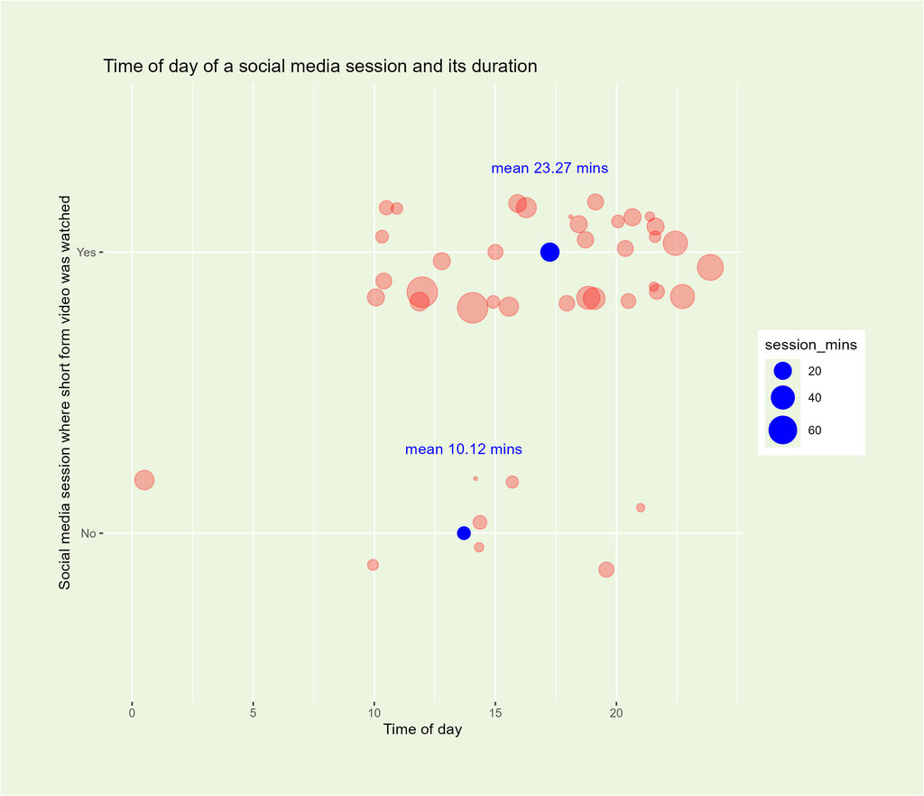

Jitter plot showing the time of day of a social media session, its durations and if during that session shorts were watched. There is a large grouping of points where shorts are watched in the day. The sessions where no shorts were watched were shorter in duration.

## And the algorithm favours what?

So we’ve established that some users might spend more time on a social media site if there is short form content but what about the content itself? I picked two types of content one is low effort ‘brain rot’ and higher effort news content which requires some editorial oversight. Unsurprisingly, ‘brain rot’ out performs news by a landslide. Many people comment on the addictive nature of this type of content, and I, for one, am certainly not immune to it’s effects. While this algorithm is personally tailored to my browsing habits, I am still surprised at how frequently this low effort content appears. This certainly raises the question if we should be optimising engagement over substance in our algorithm design.

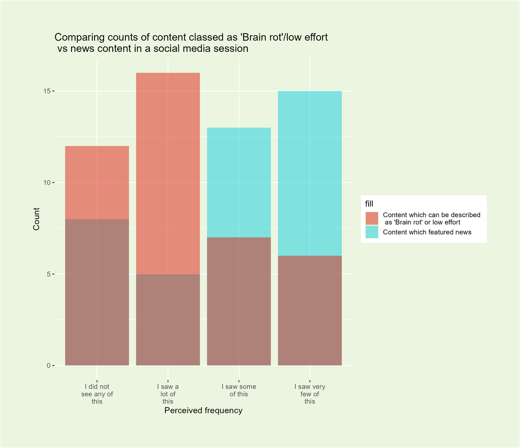

## How do things stack up?

Surprising brain rot content loses to clips of TV shows and movies as the most frequent short form content that I encounter. If I was on the executive team of a social media site I would definitely be worried at the levels copyright infringement hosted online. **So what did we learn?** We learned that my current algorithm favors pushing low effort content as well as copyright infringed works to users. This analysis has made me more aware of my browsing habits, but more over, concerned about how these algorithm are designed. I believe that copyright holders may have legitimate grounds to challenge these social media companies in court, as they algorithms are actively promoting works which they are not licensed to do.

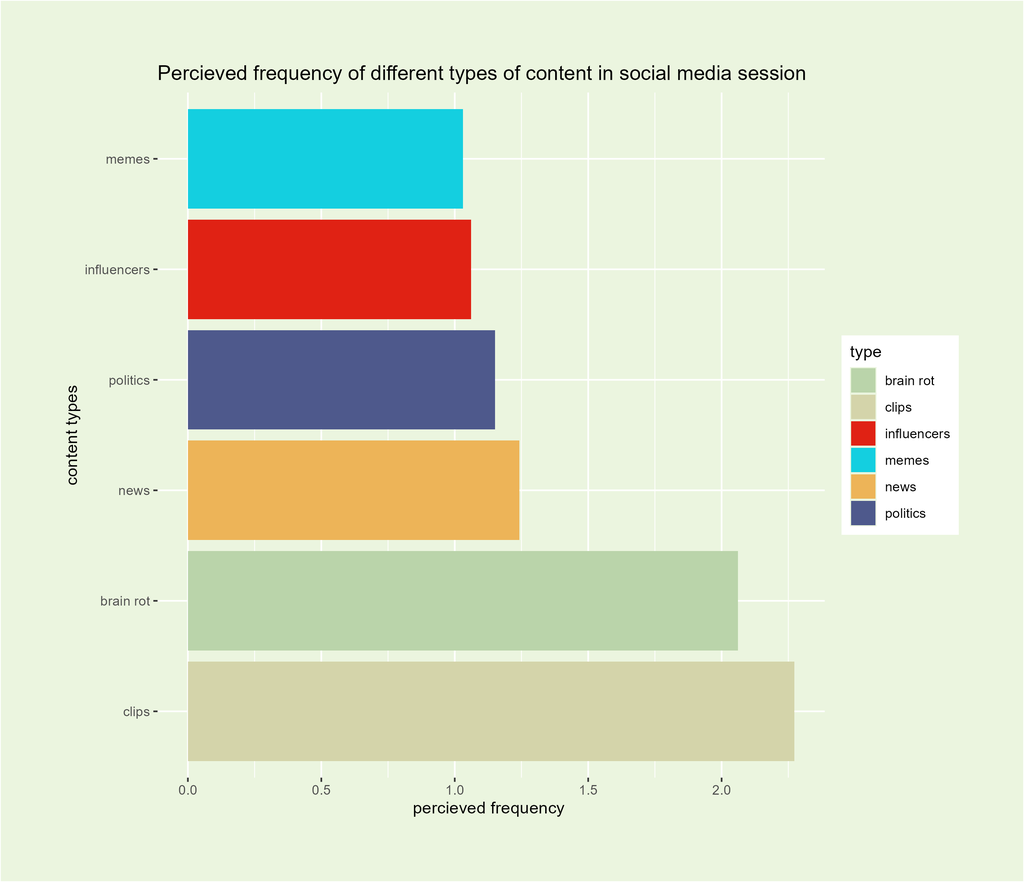

Bar graph showing perceived frequency of different types of content in a social media session. The y-axis lists content types such as memes, influencerrs, politics, news, brain rot, and clips. The x axis lists the perceived frequency. Clips and brain rot have the highest perceived frequency while memes and influencers have the lowest.

## Some examples of brain rot below

This screenshot is from a short where the voice of Peter Griffin from Family Guy using AI voice synthesis explains SQL database indexing while Minecraft parkour is played in the background. This is an new form of brain rot I recently came across affectionately known as tech brain rot.

[figure not shown]

Peter Griffin from family guy explaining sql databases

This is an example of brain rot where we have an AI voice narrating a story off of reddit while an unrelated video plays in the background.

[figure not shown]

Brain rot example where a story is being red while an unrelated lumberjack video plays in the background